# PCA code for publish

Josephine Estelle Ananda Connelly

2023-06-06

```r
#vsFirst time
#if (!requireNamespace("BiocManager", quietly = TRUE))
#    install.packages("BiocManager")
#
#BiocManager::install("SNPRelate")
```

```r
#Loading VCF file
vcf.fn<- "~/R-project-soy/resources/start_data/intersect_filtered/intersect_filtered.vcf.gz"
```

Parsing turn the VCF file into a less data intensive form (GDS) for easier computing.

```r
#snprelate
#Make sure all gds objectsare closed to start off
showfile.gds(closeall=TRUE)
#make a gds object
snpgdsVCF2GDS(vcf.fn,"filtereddata.gds",method ="biallelic.only")
```

```
## Start file conversion from VCF to SNP GDS ...
## Method: extracting biallelic SNPs
## Number of samples: 574
## Parsing "~/R-project-soy/resources/start_data/intersect_filtered/intersect_filtered.vcf.gz" ...
##  import 35486 variants.
## + genotype   { Bit2 574x35486, 4.9M } *
## Optimize the access efficiency ...
## Clean up the fragments of GDS file:
##     open the file 'filtereddata.gds' (5.1M)
##     # of fragments: 52
##     save to 'filtereddata.gds.tmp'
##     rename 'filtereddata.gds.tmp' (5.1M, reduced: 384B)
##     # of fragments: 20
```

```r
#Make gds class object
filteredgds<-snpgdsOpen("filtereddata.gds")
```

# PCA

Principal Component Analysis (PCA)

The functions in SNPRelate for PCA include calculating the genetic covariance matrix from genotypes, computing the correlation coefficients between sample loadings and genotypes for each SNP, calculating SNP eigenvectors (loadings), and estimating the sample loadings of a new dataset from specified SNP eigenvectors.

```r
# Run PCA
pca1 <- snpgdsPCA(filteredgds, sample.id=filteredgds$sample.id, snp.id=filteredgds$snp.id,
    autosome.only=FALSE, remove.monosnp=TRUE, maf=NaN, missing.rate=NaN,
    bayesian=FALSE, need.genmat=FALSE,
    genmat.only=FALSE, verbose=TRUE)
```

```
## Principal Component Analysis (PCA) on genotypes:
## Excluding 0 SNP (monomorphic: TRUE, MAF: NaN, missing rate: NaN)
##     # of samples: 574
##     # of SNPs: 35,486
##     using 1 thread
##     # of principal components: 32
## PCA:    the sum of all selected genotypes (0,1,2) = 23921959
## CPU capabilities:
## Tue Jun  6 11:05:01 2023    (internal increment: 856)
##
[..................................................]  0%, ETC: ---
[==================================================] 100%, completed, 8s
## Tue Jun  6 11:05:09 2023    Begin (eigenvalues and eigenvectors)
## Tue Jun  6 11:05:09 2023    Done.
```

```r
# variance proportion (%)
pc.percent <- pca1$varprop*100
head(round(pc.percent, 2))
```

```
## [1] 10.29  3.43  2.62  1.97  1.87  1.68
```

new numbers: [1] 10.29 3.43 2.62 1.97 1.87 1.68 old data: [1] 10.18 3.38 2.65 1.96 1.85 1.69 Use PC1 and PC2

Id like to upload my annotation file and use that:

```r
#Upload data
annotation <- read.csv("~/R-project-soy/resources/start_data/intersect_filtered/annotation_intersect_filtered.csv")

#how they did it in the tutorial? datacode <- scan(annotation$data_code, what=character())
#datacode = annotation %>% dplyr::select(c(data_code))
datacode <- c(annotation$data_code)
#get sample id
sample.id <- read.gdsn(index.gdsn(filteredgds, "sample.id"))
#bind
cbind(sample.id, datacode)
```

```
##        sample.id   datacode
##   [1,] "001A"      "SBPA"
##   [2,] "002A"      "SBPA"
##   [3,] "003A"      "SBPA"
##   [4,] "004A"      "SBPA"
##   [5,] "005A"      "SBPA"
##   [6,] "006A"      "SBPA"
##   [7,] "007A"      "SBPA"
##   [8,] "012A"      "SBPA"
##   [9,] "013A"      "SBPA"
##  [10,] "014A"      "SBPA"
##  [11,] "015A"      "SBPA"
##  [12,] "016A"      "SBPA"
##  [13,] "017A"      "SBPA"
##  [14,] "018A"      "SBPA"
```

[output cut: 560 more lines]

```r
tab <- data.frame(sample.id = pca1$sample.id,
    pop = factor(datacode)[match(pca1$sample.id, sample.id)],
    EV1 = pca1$eigenvect[,1],    # the first eigenvector
    EV2 = pca1$eigenvect[,2],    # the second eigenvector
    stringsAsFactors = FALSE)
head(tab)
```

```
##   sample.id  pop         EV1          EV2
## 1      001A SBPA -0.04687105  0.020244801
## 2      002A SBPA -0.07108486  0.013367251
## 3      003A SBPA -0.06563097 -0.005856674
## 4      004A SBPA -0.05497388  0.009145386
## 5      005A SBPA -0.04604327  0.008361465
## 6      006A SBPA  0.02359505 -0.031400546
```

# PCA plot

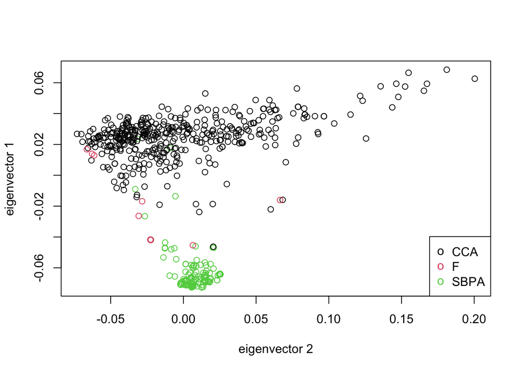

```r
plot(tab$EV2, tab$EV1, col=as.integer(tab$pop), xlab="eigenvector 2", ylab="eigenvector 1")
legend("bottomright", legend=levels(tab$pop), pch="o", col=1:nlevels(tab$pop))
```

```r
pdf(file="/Users/josephinelovemachine/R-project-soy/results/StartfileR_2_filtered/plot_PCA_source.pdf", 10, 10)
plot(tab$EV2, tab$EV1, col=as.integer(tab$pop), xlab="eigenvector 2", ylab="eigenvector 1")
legend("bottomright", legend=levels(tab$pop), pch="o", col=1:nlevels(tab$pop))
dev.off()
```